# (Loan amounts correlations with other attributes)

## by (Yasser Hamamy)

## Investigation Overview

> Finding out the best-fit prediction for Loan amounts and the correlations between other attributes.

## Dataset Overview

> The dataset consisted of 113,937 loans. The is a lots of attributes such as original loan amount, borrower's Prosper rating, loan term, borrower's stated monthly income, also there is many features such as borrower's employment status, current loan status.

## (Loan Original amount Distribution)

> We can observe from the large spikes that most of the loans are multiples of 5K.

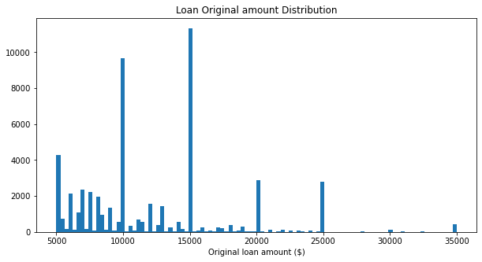

## (Income Range vs Loan Amount and Term)

There is a positive correlation between income ranges, Loan amount and loan terms as the income range increased the loan amount and loan terms also increased except for the amount $0, as it might be missing data.

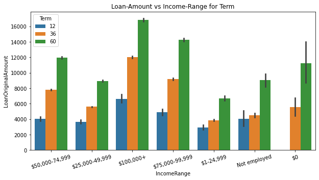

## (Loan Amount vs Employment Status)

The highest borrowers Employment Status from the loan amount are the `Employed`

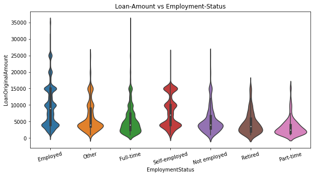

## (Employment Status vs Term)

> It appears that the `3-Year` term is the most preferable term among the Employment Status

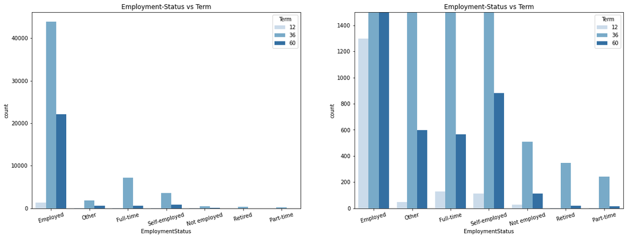

## Conclusion

> `Employed` who represent the highest share in loans amount prefer mid loan's term which is mostly the multiples of 5K.